# S2: analysis of pupil sizes with brms

I. S. Plank

2025-09-14

# 1 Introduction

## 1.1 Some general settings

```r
# number of simulations
nsim = 250

# set number of iterations and warmup for models
iter = 6000
warm = 1500

# set the maximum treedepth
max_depth = 15

# set the seed
set.seed(2468)
```

## 1.2 Package versions

The following packages are used in this RMarkdown file:

```
## [1] "R version 4.5.1 (2025-06-13)"
```

```
## [1] "knitr version 1.50"
## [1] "ggplot2 version 3.5.2"
## [1] "brms version 2.22.0"
## [1] "designr version 0.1.13"
## [1] "bridgesampling version 1.1.2"
## [1] "tidyverse version 2.0.0"
## [1] "ggpubr version 0.6.1"
## [1] "ggrain version 0.0.4"
## [1] "bayesplot version 1.13.0"
## [1] "SBC version 0.3.0.9000"
## [1] "rstatix version 0.7.2"
## [1] "effectsize version 1.0.1"
## [1] "BayesFactor version 0.9.12.4.7"
## [1] "bayestestR version 0.17.0"
```

## 1.3 Introduction

We planned to determine the group-level effect subjects following Barr (2013). For each model, experiment specific priors were set based on previous literature or the task (see comments in the code).

## 1.4 Preparation

First, we load the data and print how many participants in each group.

```r
# load the behavioural data
load("../data/PAL-ADHD_data.RData")

# load the pupil size data and the diagnosis
df = read_csv(file.path('../data', 'ADHD_CV_pup_sum', "CV_data_C(expected, Sum)[S.expected].csv"),
              show_col_types = F) %>%
  merge(., df.tsk %>% select(subID, diagnosis) %>% distinct(),
        all = T) %>%
  filter(diagnosis != "ASD") %>%
  drop_na() %>% droplevels() %>%
  mutate_if(is.character, as.factor)

# print the number of participants per group
kable(df %>% select(subID, diagnosis) %>% distinct() %>% group_by(diagnosis) %>% count())
```

| diagnosis | n |
| --- | --- |
| ADHD | 17 |
| BOTH | 22 |
| COMP | 18 |

```r
# print the contrasts
contrasts(df$diagnosis) = contr.sum(3)
contrasts(df$diagnosis)
```

```
##      [,1] [,2]
## ADHD    1    0
## BOTH    0    1
## COMP   -1   -1
```

```r
contrasts(df$expected)  = contr.sum(2)
contrasts(df$expected)
```

```
##            [,1]
## expected      1
## unexpected   -1
```

# 2 Pupil size extracted using CV

## 2.1 Model setup

```r
# model formula
f.pup = brms::bf(rel_pupil ~ diagnosis * expected + rts +
                   (1 | subID)
                 )

# set weakly informative priors
priors = c(
  prior(normal(0,    0.10),  class = Intercept),
  prior(normal(0.15, 0.15),  class = sigma),
  prior(normal(0.15, 0.15),  class = sd),
  prior(normal(0,    0.05),  class = b)
)

kable(priors)
```

| prior | class | coef | group | resp | dpar | nlpar | lb | ub | source |
| --- | --- | --- | --- | --- | --- | --- | --- | --- | --- |
| normal(0, 0.1) | Intercept |  |  |  |  |  | NA | NA | user |
| normal(0.15, 0.15) | sigma |  |  |  |  |  | NA | NA | user |
| normal(0.15, 0.15) | sd |  |  |  |  |  | NA | NA | user |
| normal(0, 0.05) | b |  |  |  |  |  | NA | NA | user |

## 2.2 Posterior predictive checks

As the next step, we fit the model, check whether there are divergence or rhat issues, and then check whether the chains have converged.

```r
# fit the final model
m.pup = brm(f.pup, seed = 6644,
            df, prior = priors,
            iter = iter, warmup = warm,
            init = 0.1,
            control = list(max_treedepth = max_depth),
            backend = "cmdstanr", threads = threading(2),
            file = file.path(brms_dir, "m_pup"),
            save_pars = save_pars(all = TRUE)
            )
rstan::check_divergences(m.pup$fit)
```

```
## 0 of 18000 iterations ended with a divergence.
```

```r
rstan::check_energy(m.pup$fit)
```

```
## E-BFMI indicated no pathological behavior.
```

```r
# check_treedepth takes treedepth 10 which we already increased,
# so we check this manually
sparams  = rstan::get_sampler_params(m.pup$fit, inc_warmup = FALSE)
exceedtd = do.call(rbind, sparams)[, "treedepth__"] >= max_depth
message(
      sprintf('%s of %s iterations saturated the maximum tree depth of %s (%.3f%%).',
              sum(exceedtd),
              length(exceedtd),
              max_depth,
              100 * sum(exceedtd) / length(exceedtd))
    )
```

```
## 0 of 18000 iterations saturated the maximum tree depth of 15 (0.000%).
```

```r
# check that rhats are below 1.01
sum(brms::rhat(m.pup) >= 1.01, na.rm = T)
```

```
## [1] 0
```

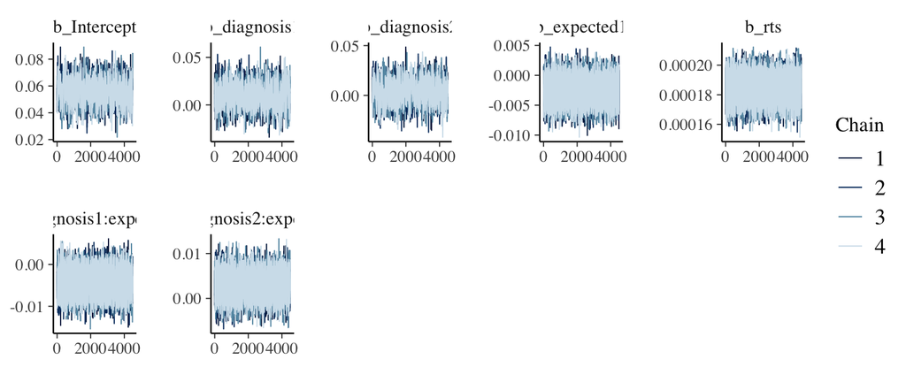

```r
# check the trace plots
post.draws = as_draws_df(m.pup)
mcmc_trace(post.draws, regex_pars = "^b_",
           facet_args = list(ncol = 5)) +
  scale_x_continuous(breaks=scales::pretty_breaks(n = 3)) +
  scale_y_continuous(breaks=scales::pretty_breaks(n = 3))
```

This model has no pathological behaviour with E-BFMI, no divergent sample and no rhats that are higher or equal to 1.01. Furthermore, there are no iterations where the maximum treedepth is exceeded. Therefore, we go ahead and perform our posterior predictive checks.

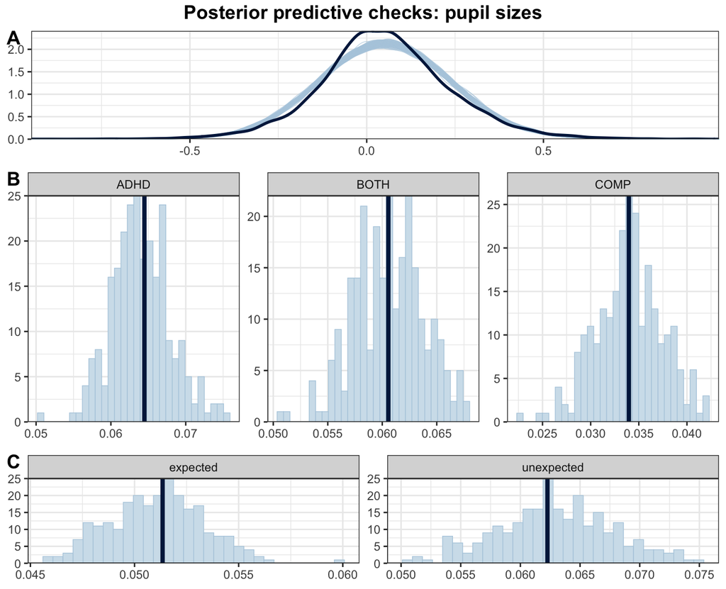

```r
# get posterior predictions
post.pred = posterior_predict(m.pup, ndraws = nsim)

# check the fit of the predicted data compared to the real data
p1 = pp_check(m.pup, ndraws = nsim) +
  theme_bw() + theme(legend.position = "none")

# distributions of means compared to the real values per group
p2 = ppc_stat_grouped(df$rel_pupil, post.pred, df$diagnosis) +
  theme_bw() + theme(legend.position = "none")

# distributions of means compared to the real values per group
p3 = ppc_stat_grouped(df$rel_pupil, post.pred, df$expected) +
  theme_bw() + theme(legend.position = "none")

p = ggarrange(p1, p2, p3, heights = c(1,2,1),
          nrow = 3, ncol = 1, labels = "AUTO")
annotate_figure(p, top = text_grob("Posterior predictive checks: pupil sizes",
                                   face = "bold", size = 14))
```

The simulated data based on the model fits reasonably well with the real data.

## 2.3 Inferences

Now that we are convinced that we can trust our model, we have a look at its estimate and use the hypothesis function to assess our hypothesis and explore the data.

```r
# print a summary
summary(m.pup)
```

```
##  Family: gaussian
##   Links: mu = identity; sigma = identity
## Formula: rel_pupil ~ diagnosis * expected + rts + (1 | subID)
##    Data: df (Number of observations: 14661)
##   Draws: 4 chains, each with iter = 6000; warmup = 1500; thin = 1;
##          total post-warmup draws = 18000
##
## Multilevel Hyperparameters:
## ~subID (Number of levels: 57)
##               Estimate Est.Error l-95% CI u-95% CI Rhat Bulk_ESS Tail_ESS
## sd(Intercept)     0.06      0.01     0.05     0.07 1.00     1831     3420
##
## Regression Coefficients:
##                      Estimate Est.Error l-95% CI u-95% CI Rhat Bulk_ESS
## Intercept                0.06      0.01     0.04     0.07 1.01     1301
## diagnosis1               0.01      0.01    -0.01     0.03 1.00     1276
## diagnosis2               0.00      0.01    -0.02     0.03 1.00     1087
## expected1               -0.00      0.00    -0.01     0.00 1.00    38787
## rts                      0.00      0.00     0.00     0.00 1.00    20007
## diagnosis1:expected1    -0.00      0.00    -0.01     0.00 1.00    21529
## diagnosis2:expected1     0.00      0.00    -0.00     0.01 1.00    21870
##                      Tail_ESS
## Intercept                2673
## diagnosis1               2062
## diagnosis2               1993
## expected1               12036
## rts                     15436
## diagnosis1:expected1    14814
## diagnosis2:expected1    13960
##
## Further Distributional Parameters:
##       Estimate Est.Error l-95% CI u-95% CI Rhat Bulk_ESS Tail_ESS
## sigma     0.18      0.00     0.17     0.18 1.00    20066    11972
##
## Draws were sampled using sample(hmc). For each parameter, Bulk_ESS
## and Tail_ESS are effective sample size measures, and Rhat is the potential
## scale reduction factor on split chains (at convergence, Rhat = 1).
```

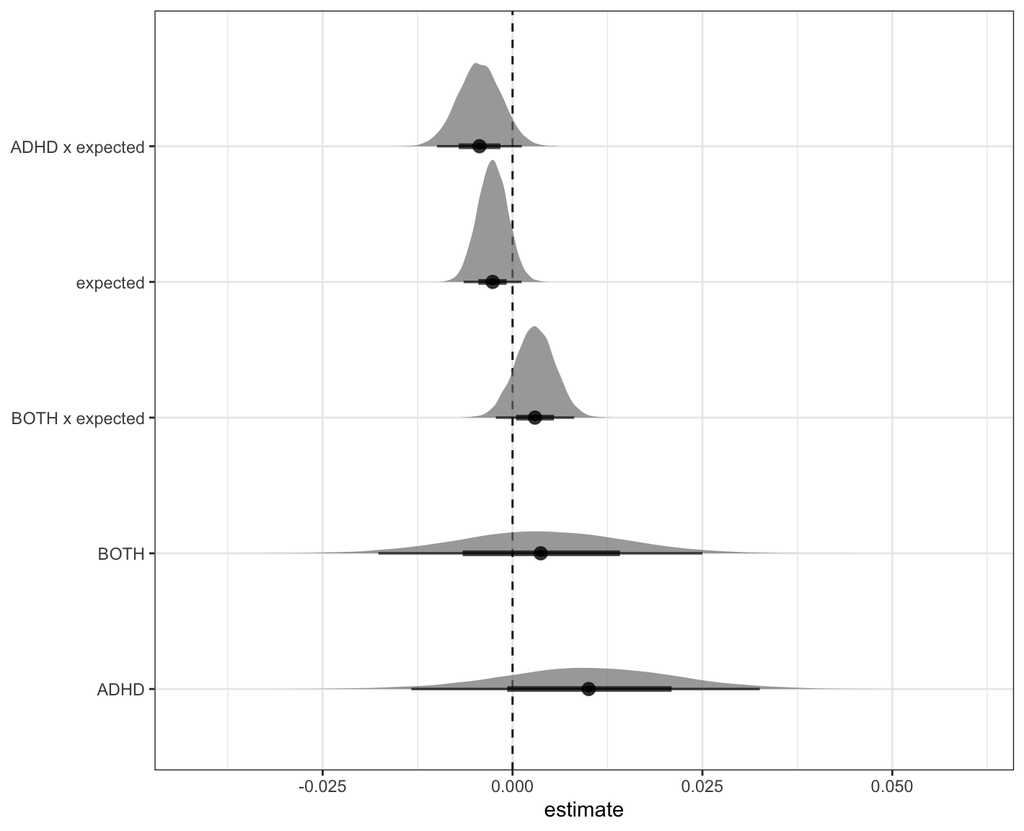

```r
# plot the posterior distributions
post.draws %>%
  select(starts_with("b_"), -b_rts) %>%
  pivot_longer(cols = starts_with("b_"), names_to = "coef", values_to = "estimate") %>%
  subset(!startsWith(coef, "b_Int")) %>%
  mutate(
    coef = substr(coef, 3, nchar(coef)),
    coef = str_replace_all(coef, ":", " x "),
    coef = str_replace_all(coef, "diagnosis1", "ADHD"),
    coef = str_replace_all(coef, "diagnosis2", "BOTH"),
    coef = str_replace_all(coef, "expected1", "expected"),
    coef = fct_reorder(coef, desc(estimate))
  ) %>%
  group_by(coef) %>%
  mutate(
    cred = case_when(
      (mean(estimate) < 0 & quantile(estimate, probs = 0.975) < 0) |
        (mean(estimate) > 0 & quantile(estimate, probs = 0.025) > 0) ~ "credible",
      T ~ "not credible"
    )
  ) %>% ungroup() %>%
  ggplot(aes(x = estimate, y = coef, fill = cred)) +
  geom_vline(xintercept = 0, linetype = 'dashed') +
  ggdist::stat_halfeye(alpha = 0.7) + ylab(NULL) + theme_bw() +
  scale_fill_manual(values = c(credible = c_dark, c_light)) + theme(legend.position = "none")
```

```r
# get the design matrix to figure out how to set the contrasts
df.des = cbind(df, model.matrix(~ diagnosis * expected, data = df)) %>%
  select(starts_with("diagn") | starts_with("expect")) %>% distinct() %>%
  relocate(diagnosis, expected)

# explore expectancy effect
e.exp = hypothesis(m.pup, "0 > 2*expected1", alpha = 0.025)
e.exp
```

```
## Hypothesis Tests for class b:
##              Hypothesis Estimate Est.Error CI.Lower CI.Upper Evid.Ratio
## 1 (0)-(2*expected1) > 0     0.01         0        0     0.01      10.06
##   Post.Prob Star
## 1      0.91
## ---
## 'CI': 95%-CI for one-sided and 97.5%-CI for two-sided hypotheses.
## '*': For one-sided hypotheses, the posterior probability exceeds 97.5%;
## for two-sided hypotheses, the value tested against lies outside the 97.5%-CI.
## Posterior probabilities of point hypotheses assume equal prior probabilities.
```

```r
# H2b: COMP(unexp - exp) != ADHD(unexp - exp)
t(df.des %>% filter(diagnosis != "BOTH") %>%
    group_by(diagnosis) %>%
    summarise(across(where(is.numeric), ~ diff(.x))) %>% # unexpected - expected
    arrange(diagnosis) %>%
    select(where(is.numeric)) %>%
    map_df(~ diff(.x))) # COMP(unexpected - expected) - ADHD(unexpected - expected)
```

```
##                      [,1]
## diagnosis1              0
## diagnosis2              0
## diagnosis1:expected1    4
## diagnosis2:expected1    2
## expected1               0
```

```r
h2b = hypothesis(m.pup, "0 > (4*diagnosis1:expected1 + 2*diagnosis2:expected1)")
h2b
```

```
## Hypothesis Tests for class b:
##                 Hypothesis Estimate Est.Error CI.Lower CI.Upper Evid.Ratio
## 1 (0)-((4*diagnosis... > 0     0.01      0.01    -0.01     0.03       6.83
##   Post.Prob Star
## 1      0.87
## ---
## 'CI': 90%-CI for one-sided and 95%-CI for two-sided hypotheses.
## '*': For one-sided hypotheses, the posterior probability exceeds 95%;
## for two-sided hypotheses, the value tested against lies outside the 95%-CI.
## Posterior probabilities of point hypotheses assume equal prior probabilities.
```

```r
# calculate effect sizes
df.effect = post.draws %>%
  mutate(across(starts_with("sd")|starts_with("sigma"), ~.^2)) %>%
  mutate(
    sumvar = sqrt(rowSums(select(., starts_with("sd")|starts_with("sigma")))),
    h2b    = -(4*`b_diagnosis1:expected1` + 2*`b_diagnosis2:expected1`) / sumvar
  )

kable(df.effect %>% select(starts_with("e")|starts_with("h")) %>%
        pivot_longer(cols = everything(), values_to = "estimate") %>%
        group_by(name) %>%
        summarise(
          ci.lo = lower_ci(estimate),
          mean  = mean(estimate),
          ci.hi = upper_ci(estimate),
          interpret = interpret_cohens_d(mean)
        ), digits = 3
)
```

| name | ci.lo | mean | ci.hi | interpret |
| --- | --- | --- | --- | --- |
| h2b | -0.046 | 0.062 | 0.166 | very small |

h2b: COMP(unexpected-expected) vs. ADHD(unexpected-expected): *estimate* = 0.01 [-0.01, 0.03], *posterior probability* = 87.22%

## 2.4 Plots

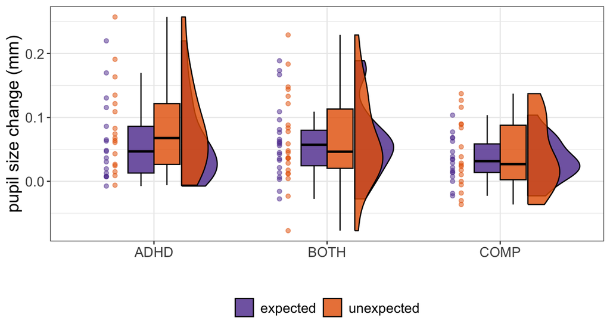

```r
# rain cloud plot
df %>%
  group_by(subID, diagnosis, expected) %>%
  summarise(
    rel_pupil = mean(rel_pupil)
  ) %>%
  ggplot(aes(diagnosis, rel_pupil, fill = expected, colour = expected)) + #
  geom_rain(rain.side = 'r',
boxplot.args = list(color = "black", outlier.shape = NA, show.legend = FALSE, alpha = .8),
violin.args = list(color = "black", outlier.shape = NA, alpha = .8),
boxplot.args.pos = list(
  position = ggpp::position_dodgenudge(x = 0, width = 0.3), width = 0.3
),
point.args = list(show_guide = FALSE, alpha = .5),
violin.args.pos = list(
  width = 0.6, position = position_nudge(x = 0.16)),
point.args.pos = list(position = ggpp::position_dodgenudge(x = -0.25, width = 0.1))) +
  scale_fill_manual(values = col.cnd) +
  scale_color_manual(values = col.cnd) +
  labs(title = "", x = "", y = "pupil size change (mm)") +
  theme_bw() +
  theme(legend.position = "bottom", plot.title = element_blank(),
        legend.direction = "horizontal", text = element_text(size = 15),
        legend.title = element_blank())
```

```r
ggsave("plots/FigPUP.svg", units = "cm", width = 27, height = 9)
```